title: “Budwiser EDA” authors: “Anthony and Damilola” date: “02/27/2024” output: html_document editor_options: chunk_output_type: console —

#### Introduction:

Good afternoon Mr. Whitworth and Mr. Tennenbaum. We are here today to present the findings from the questions presented to our team of Data Scientist. We will answer the nine questions provided ahead of time with our analysis and visualuations, as well as highlighting any key observations that came up during our review. With that, let us get started as we’re excited to share with you the breakdown of our findings.

Installing the packages

```r
#install.packages("tidyverse")
#install.packages("ggplot2")
#install.packages("GGally")
#install.packages("dplyr")
#install.packages("maps")
#install.packages("mapsproj")
library(ggplot2)
library(tidyverse)
library(GGally)
library(dplyr)
library(class)
library(caret)
library(e1071)
library(maps)
library(mapproj)
```

#### Agenda 1a: Distribution by State - Load files and confirm, how many breweries are located in each state?

```r
#Load file #1 Beers.csv
Beers = read.csv(file.choose(),header = TRUE) #load the first file
head(Beers) #confirm the file is correct, review
```

```
##                  Name Beer_ID   ABV IBU Brewery_id
## 1            Pub Beer    1436 0.050  NA        409
## 2         Devil's Cup    2265 0.066  NA        178
## 3 Rise of the Phoenix    2264 0.071  NA        178
## 4            Sinister    2263 0.090  NA        178
## 5       Sex and Candy    2262 0.075  NA        178
## 6        Black Exodus    2261 0.077  NA        178
##                            Style Ounces
## 1            American Pale Lager     12
## 2        American Pale Ale (APA)     12
## 3                   American IPA     12
## 4 American Double / Imperial IPA     12
## 5                   American IPA     12
## 6                  Oatmeal Stout     12
```

```r
#Load file #2 Breweries.csv
Breweries = read.csv(file.choose(),header = TRUE) #load the second file
head(Breweries) #confirm the file is correct, review
```

```
##   Brew_ID                      Name          City State
## 1       1        NorthGate Brewing    Minneapolis    MN
## 2       2 Against the Grain Brewery    Louisville    KY
## 3       3  Jack's Abby Craft Lagers    Framingham    MA
## 4       4 Mike Hess Brewing Company     San Diego    CA
## 5       5   Fort Point Beer Company San Francisco    CA
## 6       6     COAST Brewing Company    Charleston    SC
```

```r
summary(Breweries) #check the type
```

```
##     Brew_ID          Name               City              State
##  Min.   :  1.0   Length:558         Length:558         Length:558
##  1st Qu.:140.2   Class :character   Class :character   Class :character
##  Median :279.5   Mode  :character   Mode  :character   Mode  :character
##  Mean   :279.5
##  3rd Qu.:418.8
##  Max.   :558.0
```

```r
mean_count <- mean(Breweries$n) #create a column mean_count for the reference line
```

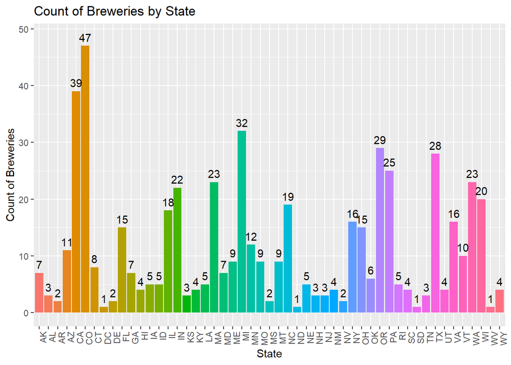

```r
Breweries %>% group_by(State) %>% summarize(n = n()) %>% ggplot(aes(x = State, y = n, fill = State)) +
  geom_bar(stat = "identity") + theme(legend.position = "none") + geom_text(aes(label = n, y = n +1.5)) +
  ggtitle("Count of Breweries by State") + ylab("Count of Breweries") + xlab("State") +
  theme(axis.text.x = element_text(angle = 90, hjust = 1)) +
  geom_hline(yintercept = mean_count, linetype = "dotted", color = "red") # to show the mean.
```

#### Answer 1a - We provided a bar chart showing the count of breweries by state. The state with the highest count of breweries is Colorado with 47 breweries. There is a four way tie between DC, North Dakota, South Dakota, and West Virginia for the lowest with one brewery each. The mean count of breweries per state is eleven.

#### Agenda 1b: Distribution by State - Load files and confirm, how many breweries are located in each state?

```r
lookup = data.frame(State = state.abb, State_Name = state.name) #makes a dataframe with State name and state abb.
head(lookup)
```

```
##   State State_Name
## 1    AL    Alabama
## 2    AK     Alaska
## 3    AZ    Arizona
## 4    AR   Arkansas
## 5    CA California
## 6    CO   Colorado
```

```r
Breweries2 = inner_join(Breweries,lookup, by = "State")
head(Breweries2)
```

```
##   Brew_ID                      Name          City State     State_Name
## 1       1        NorthGate Brewing    Minneapolis    MN      Minnesota
## 2       2 Against the Grain Brewery    Louisville    KY       Kentucky
## 3       3  Jack's Abby Craft Lagers    Framingham    MA  Massachusetts
## 4       4 Mike Hess Brewing Company     San Diego    CA     California
## 5       5   Fort Point Beer Company San Francisco    CA     California
## 6       6     COAST Brewing Company    Charleston    SC South Carolina
```

```r
BreweriesMapData = Breweries2 %>% group_by(State) %>% count(State_Name)
head(BreweriesMapData)
```

```
## # A tibble: 6 × 3
## # Groups:   State [6]
##   State State_Name     n
##   <chr> <chr>      <int>
## 1 AK    Alaska         7
## 2 AL    Alabama        3
## 3 AR    Arkansas       2
## 4 AZ    Arizona       11
## 5 CA    California    39
## 6 CO    Colorado      47
```

```r
colnames(BreweriesMapData)[3] = "Breweries" #change 'n' to 'Breweries'
BreweriesMapData$region <- tolower(BreweriesMapData$State_Name)
head(BreweriesMapData)
```

```
## # A tibble: 6 × 4
## # Groups:   State [6]
##   State State_Name Breweries region
##   <chr> <chr>          <int> <chr>
## 1 AK    Alaska             7 alaska
## 2 AL    Alabama            3 alabama
## 3 AR    Arkansas           2 arkansas
## 4 AZ    Arizona           11 arizona
## 5 CA    California        39 california
## 6 CO    Colorado          47 colorado
```

```r
BreweriesMapData2 = BreweriesMapData[-1] #drop the first column
states <- map_data("state")
head(states)
```

```
##        long      lat group order  region subregion
## 1 -87.46201 30.38968     1     1 alabama      <NA>
## 2 -87.48493 30.37249     1     2 alabama      <NA>
## 3 -87.52503 30.37249     1     3 alabama      <NA>
## 4 -87.53076 30.33239     1     4 alabama      <NA>
## 5 -87.57087 30.32665     1     5 alabama      <NA>
## 6 -87.58806 30.32665     1     6 alabama      <NA>
```

```r
map.df <- merge(states, BreweriesMapData2, by = "region", all.x = TRUE)
head(map.df)
```

```
##    region      long      lat group order subregion State_Name Breweries
## 1 alabama -87.46201 30.38968     1     1      <NA>    Alabama         3
## 2 alabama -87.48493 30.37249     1     2      <NA>    Alabama         3
## 3 alabama -87.95475 30.24644     1    13      <NA>    Alabama         3
## 4 alabama -88.00632 30.24071     1    14      <NA>    Alabama         3
## 5 alabama -88.01778 30.25217     1    15      <NA>    Alabama         3
## 6 alabama -87.52503 30.37249     1     3      <NA>    Alabama         3
```

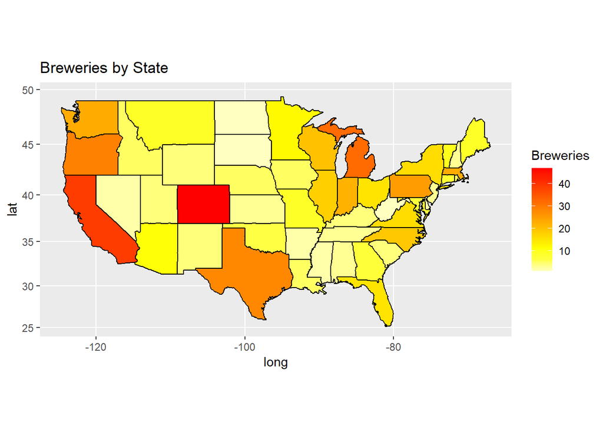

```r
map.df <-map.df[order(map.df$order),]
ggplot(map.df,aes(x = long, y = lat, group = group))+
  geom_polygon(aes(fill = Breweries)) +
  geom_path() +
  scale_fill_gradientn(colours=rev(heat.colors(10)), na.value = "grey90") + ggtitle("Breweries by State") + coord_map()
```

#### Answer 1b/9 - In addition to the bar chart, a heat map showing the distribution of breweries was included. This was added as a “knock their socks off” addition as it enhanced the answer to their question visually.

#### Question 2 - Merge beer data with the breweries data. Print the first 6 observations and the last six observations to check the merged file.

```r
merged_df = merge(Beers,Breweries, by.x = "Brewery_id", by.y = "Brew_ID") #joining when keys do not match
merged_df
```

[output not shown]

[output cut: 7218 more lines]

```r
head(merged_df,6) #to show the first 6 observations
```

```
##   Brewery_id        Name.x Beer_ID   ABV IBU
## 1          1  Get Together    2692 0.045  50
## 2          1 Maggie's Leap    2691 0.049  26
## 3          1    Wall's End    2690 0.048  19
## 4          1       Pumpion    2689 0.060  38
## 5          1    Stronghold    2688 0.060  25
## 6          1   Parapet ESB    2687 0.056  47
##                                 Style Ounces             Name.y        City
## 1                        American IPA     16 NorthGate Brewing  Minneapolis
## 2                  Milk / Sweet Stout     16 NorthGate Brewing  Minneapolis
## 3                   English Brown Ale     16 NorthGate Brewing  Minneapolis
## 4                         Pumpkin Ale     16 NorthGate Brewing  Minneapolis
## 5                     American Porter     16 NorthGate Brewing  Minneapolis
## 6 Extra Special / Strong Bitter (ESB)     16 NorthGate Brewing  Minneapolis
##   State
## 1    MN
## 2    MN
## 3    MN
## 4    MN
## 5    MN
## 6    MN
```

```r
tail(merged_df,6) #to show the last 6 observations
```

```
##      Brewery_id                    Name.x Beer_ID   ABV IBU
## 2405        556             Pilsner Ukiah      98 0.055  NA
## 2406        557  Heinnieweisse Weissebier      52 0.049  NA
## 2407        557           Snapperhead IPA      51 0.068  NA
## 2408        557         Moo Thunder Stout      50 0.049  NA
## 2409        557         Porkslap Pale Ale      49 0.043  NA
## 2410        558 Urban Wilderness Pale Ale      30 0.049  NA
##                        Style Ounces                        Name.y          City
## 2405         German Pilsener     12         Ukiah Brewing Company         Ukiah
## 2406              Hefeweizen     12       Butternuts Beer and Ale Garrattsville
## 2407            American IPA     12       Butternuts Beer and Ale Garrattsville
## 2408      Milk / Sweet Stout     12       Butternuts Beer and Ale Garrattsville
## 2409 American Pale Ale (APA)     12       Butternuts Beer and Ale Garrattsville
## 2410        English Pale Ale     12 Sleeping Lady Brewing Company     Anchorage
##      State
## 2405    CA
## 2406    NY
## 2407    NY
## 2408    NY
## 2409    NY
## 2410    AK
```

```r
#suggestion for enhancement - rename name.x to beer_name, rename name.y to brewery_name
```

#### Answer 2 - Using merge() we brought in the Breweries csv file against the Beers csv file. The method used was when the two keys were not identical.

#### Agenda 2: Missing Values - Address the missing values in each column

```r
merged_df %>% is.na() #check for missing values , ABV and IBU
```

[output not shown]

[output cut: 2396 more lines]

```r
#Cleaning the data
merged_df <- merged_df %>% na.omit()

merged_df %>% is.na() #check for missing values , ABV and IBU
```

[output not shown]

[output cut: 1391 more lines]

```r
merged_dfna = sapply(merged_df, function(x) sum(is.na(x)))
merged_dfna #confirmed across all columns, that only ABV an IBU have n/a values
```

```
## Brewery_id     Name.x    Beer_ID        ABV        IBU      Style     Ounces
##          0          0          0          0          0          0          0
##     Name.y       City      State
##          0          0          0
```

```r
summary(merged_df) #verify type
```

```
##    Brewery_id       Name.x             Beer_ID          ABV
##  Min.   :  1.0   Length:1405        Min.   :   1   Min.   :0.02700
##  1st Qu.: 95.0   Class :character   1st Qu.: 772   1st Qu.:0.05000
##  Median :198.0   Mode  :character   Median :1439   Median :0.05700
##  Mean   :224.2                      Mean   :1415   Mean   :0.05991
##  3rd Qu.:351.0                      3rd Qu.:2069   3rd Qu.:0.06800
##  Max.   :547.0                      Max.   :2692   Max.   :0.12500
##       IBU            Style               Ounces         Name.y
##  Min.   :  4.00   Length:1405        Min.   : 8.40   Length:1405
##  1st Qu.: 21.00   Class :character   1st Qu.:12.00   Class :character
##  Median : 35.00   Mode  :character   Median :12.00   Mode  :character
##  Mean   : 42.71                      Mean   :13.51
##  3rd Qu.: 64.00                      3rd Qu.:16.00
##  Max.   :138.00                      Max.   :32.00
##      City              State
##  Length:1405        Length:1405
##  Class :character   Class :character
##  Mode  :character   Mode  :character
##
##
##
```

```r
#confirming the presence os NAs
#check_for_na <- function(data) {
# if (any(is.na(data))) {
#    return("Data contains missing values (NAs).")
#  } else {
#    return("Data does not contain missing values (NAs).")
#  }
#}

#check_for_na(merged_df)
```

#### Answer 3 - There were 62 missing values from column ABV, approximately three percent of the total. There were 1,005 missing values from column IBU. The data was review and we could not locate a relationship amongst the missing data and the qualifiers. Example, there did not appear to be an observable difference between data missing across the State data, or Brewery data. Overall, it appeared that the data was missing completely at random with no way of back tracking into an answer for the missing values.

#### Agenda 3: Mean ABV % - mean of ABV by State and bar chart

```r
#create a new df to add Mean ABV %
merged_df1 <- merged_df %>% group_by(State) %>% summarize(meanABV = mean(ABV, na.rm = TRUE)) #add column meanABV with the mean of ABV.
#confirm meanABV has been added
merged_df1
```

```
## # A tibble: 50 × 2
##    State meanABV
##    <chr>   <dbl>
##  1 AK     0.0562
##  2 AL     0.0622
##  3 AR     0.04
##  4 AZ     0.0610
##  5 CA     0.0629
##  6 CO     0.0648
##  7 CT     0.0638
##  8 DC     0.065
##  9 DE     0.055
## 10 FL     0.0628
## # ℹ 40 more rows
```

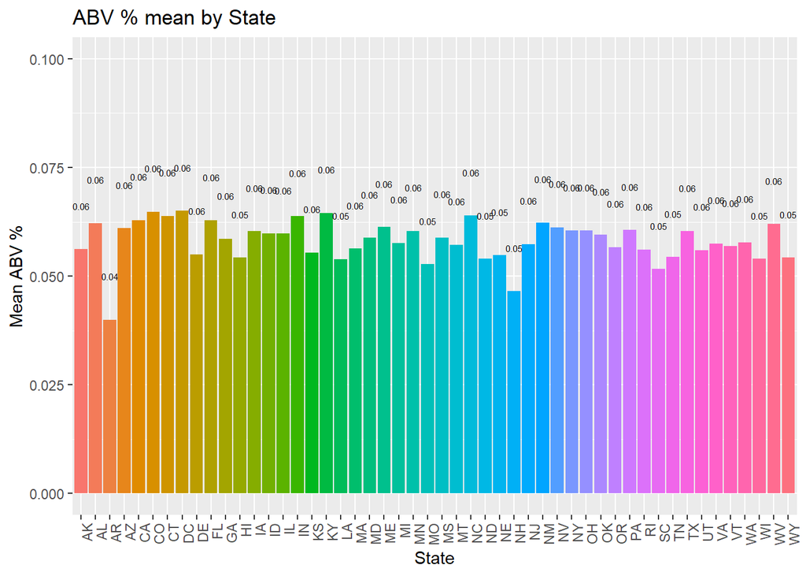

```r
#plot to show the meanABV % by state, update labels, remove legend.
ggplot(merged_df1, aes(x = State, y = meanABV, fill = State)) +
  theme(legend.position = "none") + #removed the legend
  geom_bar(stat = "identity") + geom_text(aes(label = round(meanABV, 2), y = meanABV + .01), size = 2) + #using round for cleaner looking labels
  ggtitle("ABV % mean by State") + xlab("State") + ylab("Mean ABV %") +
  ylim(0.0,0.1) + #zoom in on the y-axis for small %s
  theme(axis.text.x = element_text(angle = 90, hjust = 1))
```

#### Agenda 4: Mean IBU - mean of IBU by State and bar chart

```r
#repeat with IBU
#create a new dataframe with
merged_df2 <- merged_df %>% group_by(State) %>% summarize(meanIBU = mean(IBU, na.rm = TRUE)) #add column meanABV with the mean of IBU.
#confirm meanIBU has been added
merged_df2
```

```
## # A tibble: 50 × 2
##    State meanIBU
##    <chr>   <dbl>
##  1 AK       40.9
##  2 AL       51.2
##  3 AR       39
##  4 AZ       35.2
##  5 CA       46.3
##  6 CO       47.4
##  7 CT       40.8
##  8 DC       55.2
##  9 DE       52
## 10 FL       46.8
## # ℹ 40 more rows
```

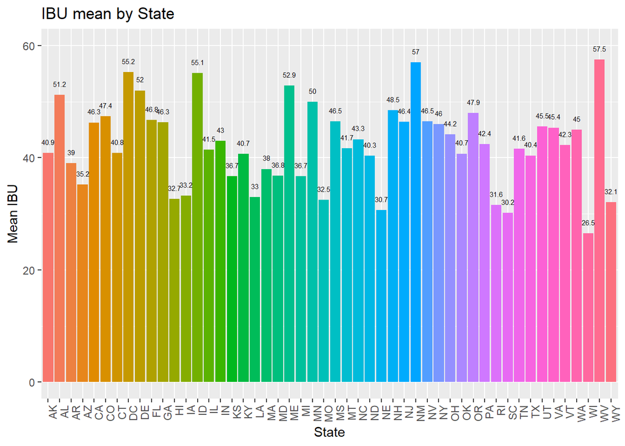

```r
#plot to show the meanIBU by state, update labels, remove legend.
ggplot(merged_df2, aes(x = State, y = meanIBU, fill = State)) +
  theme(legend.position = "none") + #removed the legend
  geom_bar(stat = "identity") + geom_text(aes(label = round(meanIBU, 1), y = meanIBU + 2), size = 2) + #using round for cleaner looking labels
  ggtitle("IBU mean by State") + xlab("State") + ylab("Mean IBU") +
  ylim(0,60) +
  theme(axis.text.x = element_text(angle = 90, hjust = 1))
```

#### Answer 4b - West Virginia has the highest mean International Bitterness Units (IBU). Due to missing values, South Dakota had no data represented. The remaining states with data were calculated and a label was added to show each. To prevent overlapping, the size of the mean labels were reduced.

#### Agenda 5 - Finding the states with the most alcoholic beer and the most bitter beer.

```r
#Which state has the maximum alcoholic (ABV) beer
merged_df %>%  filter(!is.na(ABV))
```

[output not shown]

[output cut: 4203 more lines]

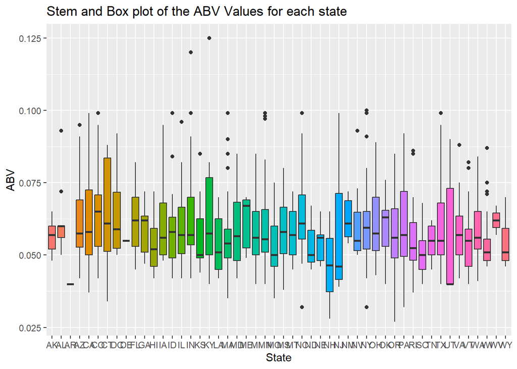

```r
maxABV <- max(merged_df[["ABV"]]) #getting the max ABV value
merged_df %>% group_by(State) %>% ggplot(aes(x = State, y = ABV, fill = State)) + theme(legend.position = "none") + geom_boxplot()  + ggtitle("Stem and Box plot of the ABV Values for each state")
```

```r
#Which state has the most bitter (IBU) beer?
MostBitterIBU <- max(merged_df[["IBU"]]) #getting the max IBU value, the higher the IBU, the more bitter the beer
MostBitterIBU
```

```
## [1] 138
```

```r
MostBitterIBU_state <- merged_df[grep(MostBitterIBU, merged_df$IBU), "State"] #finding the state for the max IBU value
MostBitterIBU_state
```

```
## [1] "OR"
```

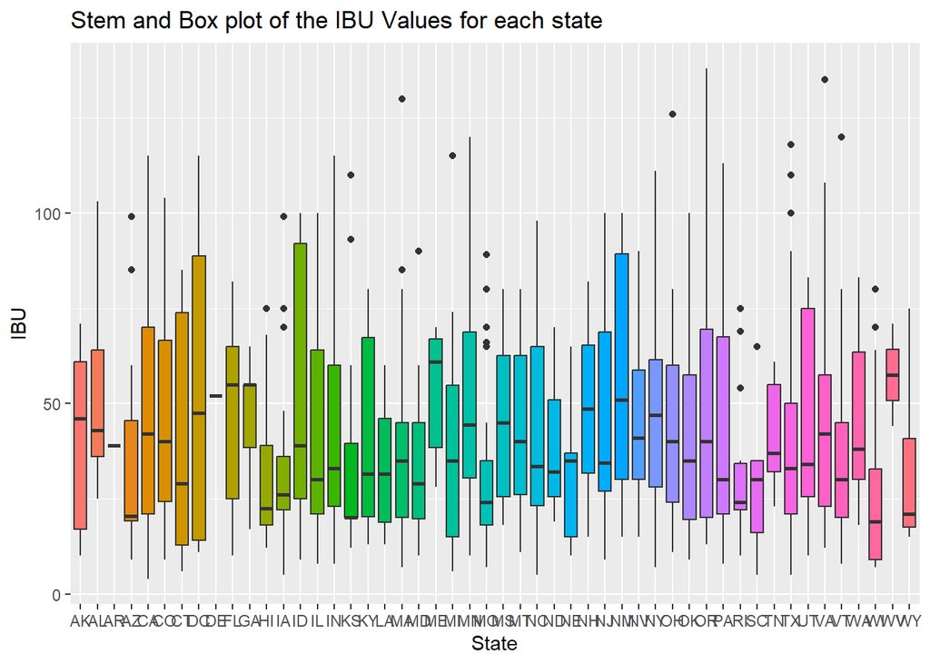

```r
merged_df %>% group_by(State) %>% ggplot(aes(x = State, y = IBU, fill = State)) + theme(legend.position = "none") + geom_boxplot()  + ggtitle("Stem and Box plot of the IBU Values for each state")
```

#### Results: The state of Kentucky possesses the most alcoholic beverage with an ABV of 12.5%, while the state of Oregon, possesses the most biter beer with an IBU of 138 units

#### Agenda 6: Investigating the summary statistics of the Alcohol By Volume Variable.

```r
#Getting the summary
summary(merged_df$ABV)
```

```
##    Min. 1st Qu.  Median    Mean 3rd Qu.    Max.
## 0.02700 0.05000 0.05700 0.05991 0.06800 0.12500
```

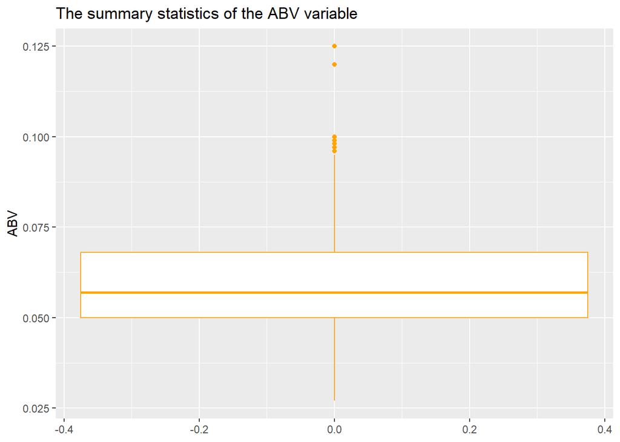

```r
MaxABV <- max(merged_df[["ABV"]])
MinABV <- min(merged_df[["ABV"]])

#Getting a  box plot for the summary
merged_df %>% group_by(ABV) %>% ggplot(aes(y = ABV)) + geom_boxplot(color = 'orange') + ggtitle("The summary statistics of the ABV variable") + theme(legend.position = "none")
```

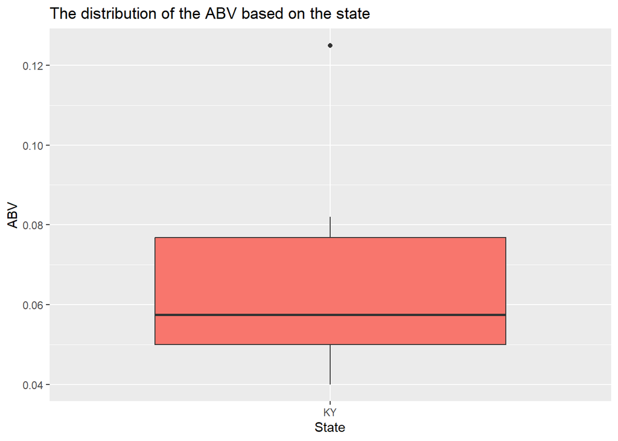

```r
#Visualizing the distribution based on the states using a box plot

#Getting the boxplot for the state with the highest ABV (Kentucky)
merged_df[grep("KY", merged_df$State), ] %>% group_by(State) %>% ggplot(aes(y = ABV, x = State, fill = State)) + geom_boxplot() + ggtitle("The distribution of the ABV based on the state") + theme(legend.position = "none")
```

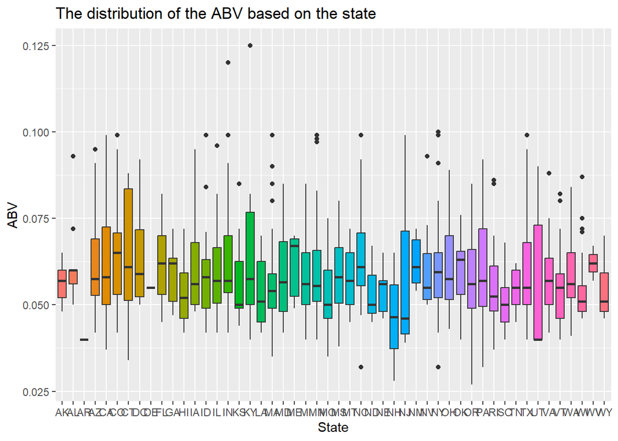

```r
#Getting the boxplot for all states
merged_df %>% group_by(State) %>% ggplot(aes(y = ABV, x = State, fill = State)) + geom_boxplot() + ggtitle("The distribution of the ABV based on the state") + theme(legend.position = "none")
```

```r
MaxABV; merged_df[grep(MaxABV, merged_df$ABV), "State"] #Getting the state of MaxABV
```

```
## [1] 0.125
```

```
## [1] "KY"
```

```r
MinABV; merged_df[grep(MinABV, merged_df$ABV), "State"] #Getting the state of MinABV
```

```
## [1] 0.027
```

```
## [1] "OR"
```

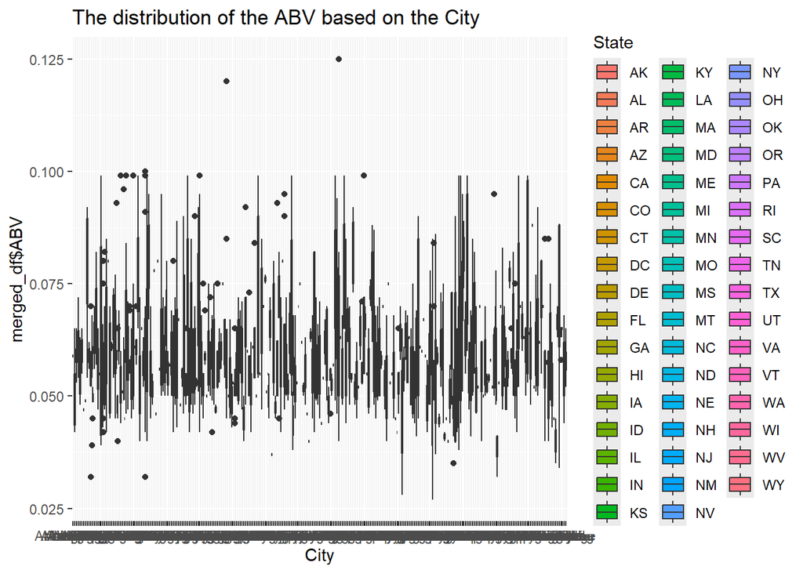

```r
#Visualizing the distribution based on the city using a barchart
merged_df %>% group_by(City) %>% ggplot(aes(y = merged_df$ABV, x = City, fill = State)) + geom_boxplot() + ggtitle("The distribution of the ABV based on the City")
```

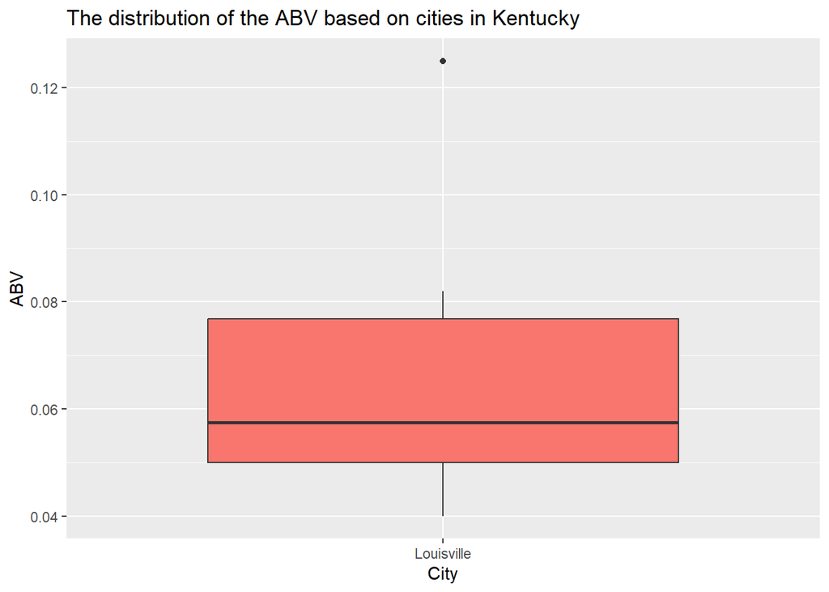

```r
#Visualizing the distribution based on the cities in Kentucky using a barchart
merged_df[grep("KY", merged_df$State), ] %>% ggplot(aes(y = ABV, x = City, fill = City)) + geom_boxplot() + ggtitle("The distribution of the ABV based on cities in Kentucky") + theme(legend.position = "none")
```

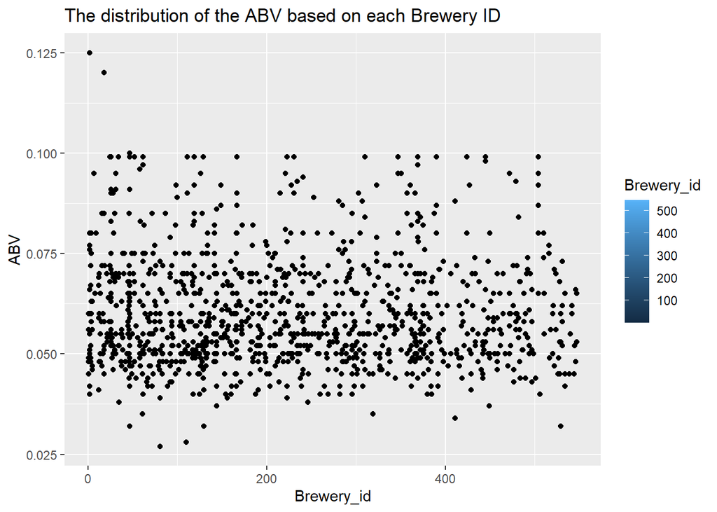

```r
#Visualizing the distribution based on the Brewery ID using a scatterplot
merged_df %>% group_by(Brewery_id) %>% ggplot(aes(y = ABV, x = Brewery_id, fill = Brewery_id)) + geom_point() + ggtitle("The distribution of the ABV based on each Brewery ID")
```

```r
MaxABV; merged_df[grep(MaxABV, merged_df$ABV), "Name.x"] #Getting the Brewery ID of MaxABV
```

```
## [1] 0.125
```

```
## [1] "London Balling"
```

```r
MinABV; merged_df[grep(MinABV, merged_df$ABV), "Name.x"] #Getting the Brewery ID of MinABV
```

```
## [1] 0.027
```

```
## [1] "Totally Radler"
```

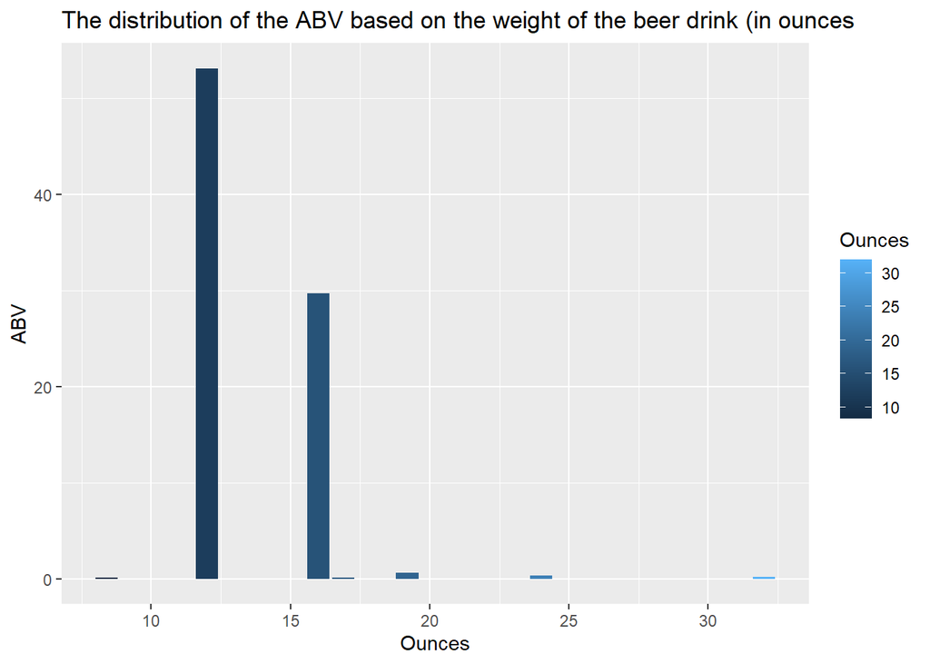

```r
#Visualizing the distribution based on the weight in ounces using a barplot
merged_df %>% group_by(Ounces) %>% ggplot(aes(y = ABV, x = Ounces, fill = Ounces)) + geom_bar(stat = "identity") + ggtitle("The distribution of the ABV based on the weight of the beer drink (in ounces")
```

```r
# The bar just shows the frequency distribution of the ABV for each weight

#Visualizing the distribution based on the IBU using a scatterplot
merged_df %>% group_by(IBU) %>% ggplot(aes(y = ABV, x = IBU, color = State)) + geom_point() + ggtitle("The distribution of the ABV based on each IBU") + theme(legend.position = "none")
```

[output not shown]

#### Agenda 6.5 : Investigating the summary statistics of the International Business Unit Variable.

```r
#Getting the summary
summary(merged_df$IBU)
```

```
##    Min. 1st Qu.  Median    Mean 3rd Qu.    Max.
##    4.00   21.00   35.00   42.71   64.00  138.00
```

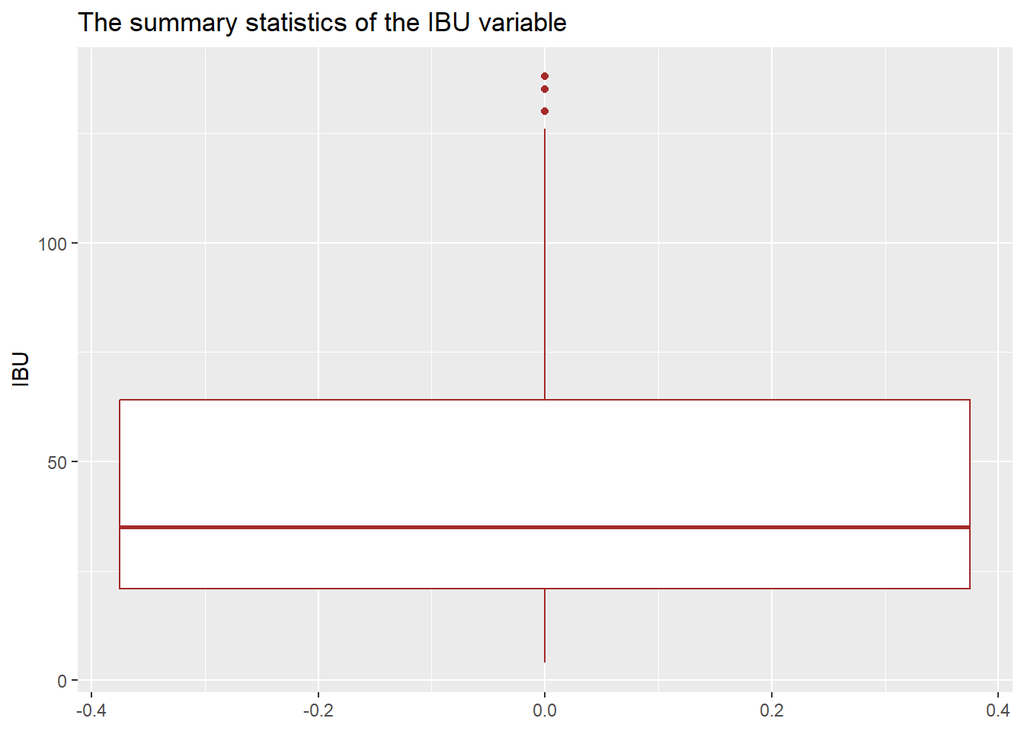

```r
MaxIBU <- max(merged_df[["IBU"]])
MinIBU <- min(merged_df[["IBU"]])

#Getting a  box plot for the summary
merged_df %>% group_by(IBU) %>% ggplot(aes(y = IBU)) + geom_boxplot(color = 'brown') + ggtitle("The summary statistics of the IBU variable") + theme(legend.position = "none")
```

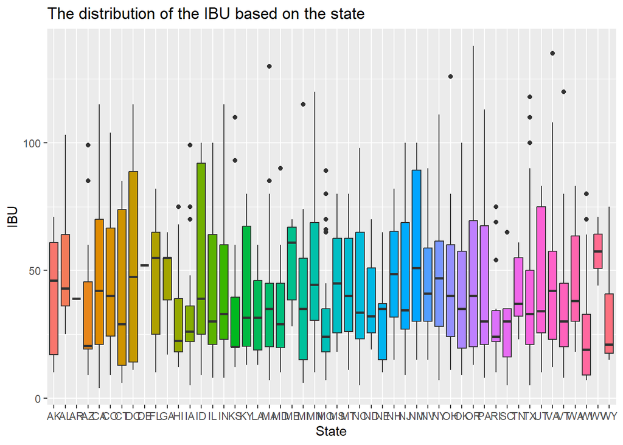

```r
#Visualizing the distribution based on the states using a box plot
merged_df %>% group_by(State) %>% ggplot(aes(y = IBU, x = State, fill = State)) + geom_boxplot() + ggtitle("The distribution of the IBU based on the state") + theme(legend.position = "none")
```

```r
MaxIBU; merged_df[grep(MaxIBU, merged_df$IBU), "State"] #Getting the state of MaxIBU
```

```
## [1] 138
```

```
## [1] "OR"
```

```r
MinIBU; merged_df[grep(MinIBU, merged_df$IBU), "State"] #Getting the state of MinIBU
```

```
## [1] 4
```

```
##   [1] "MN" "KY" "MA" "CA" "CA" "MI" "MI" "MI" "MI" "MI" "IN" "IN" "IN" "IN" "IN"
##  [16] "IN" "IN" "IN" "IN" "IN" "AZ" "AZ" "AZ" "CA" "CA" "CA" "CO" "IL" "IL" "KS"
##  [31] "NY" "NY" "NY" "NY" "NY" "NY" "NY" "CA" "CO" "MN" "IL" "MN" "MN" "MN" "MN"
##  [46] "CO" "MD" "NC" "IL" "IL" "MN" "CO" "OH" "OH" "OH" "OH" "PA" "CA" "RI" "RI"
##  [61] "MA" "CO" "CO" "CO" "CO" "CA" "OR" "TX" "TX" "TX" "VA" "VA" "VA" "VA" "TX"
##  [76] "TX" "WI" "WI" "MS" "MS" "CO" "CO" "MN" "TX" "RI" "RI" "CO" "NC" "OR" "OR"
##  [91] "OR" "OR" "OR" "OR" "OR" "WV" "UT" "UT" "AZ" "TX" "PA" "CA" "CA" "CA" "VA"
## [106] "OH" "OH" "WA" "WA" "WA" "OR" "OR" "HI" "TX" "IA" "CA" "CA" "TX" "CO" "AK"
## [121] "NY" "MA" "MA" "MA" "MA" "MA" "MA" "VA" "VA" "CA" "CT" "TX" "MN" "VT" "LA"
## [136] "AK" "VT" "NY" "MN" "MA" "CA" "NJ" "KS" "WI" "WI" "AL" "TX" "CA" "ME" "CO"
## [151] "CO" "CO" "PA" "PA" "PA" "MA" "MO" "MA" "MO" "MO" "MO" "VT" "NY" "MT" "MT"
## [166] "FL" "NY" "CA" "CA" "PA" "NC" "IL" "WA" "IA" "IA" "OK" "CA" "CA" "CA" "CA"
## [181] "CA" "CO" "CO" "PA" "PA" "OR" "HI" "RI" "RI" "RI" "TX" "CA" "WA" "CO" "CO"
## [196] "MO" "CO" "NC" "NC" "NY" "NY" "CO" "CO" "MN" "CA" "CA" "CA" "WA" "AK" "AK"
## [211] "OR" "WA" "GA" "IA" "CA" "AL" "AL" "MD" "WA" "WA" "NY" "AK" "CO" "NV" "NV"
```

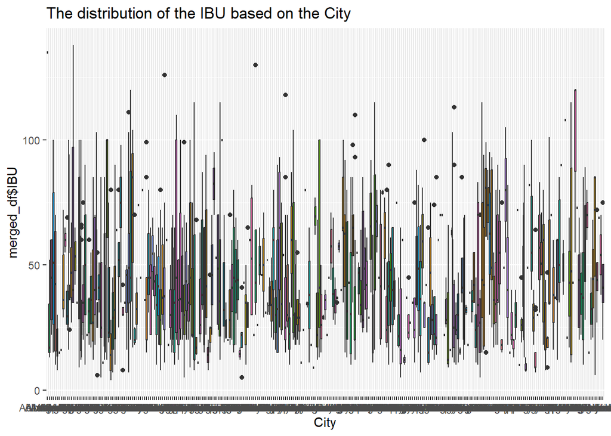

```r
#Visualizing the distribution based on the city using a barchart
merged_df %>% group_by(City) %>% ggplot(aes(y = merged_df$IBU, x = City, fill = State)) + geom_boxplot() + ggtitle("The distribution of the IBU based on the City")  + theme(legend.position = "none")
```

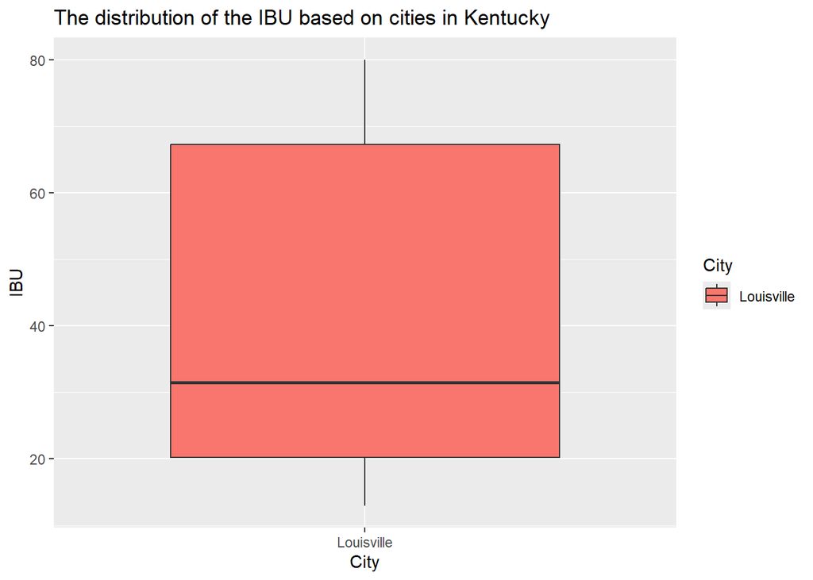

```r
#Visualizing the distribution based on the cities in Kentucky using a barchart
merged_df[grep("KY", merged_df$State), ] %>% ggplot(aes(y = IBU, x = City, fill = City)) + geom_boxplot() + ggtitle("The distribution of the IBU based on cities in Kentucky")
```

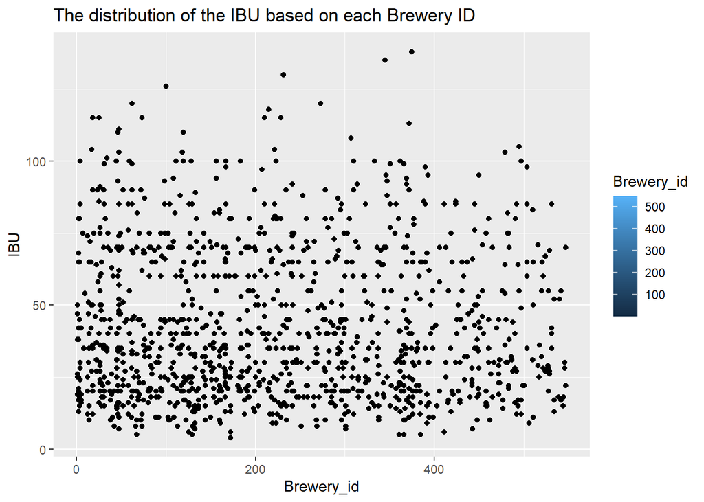

```r
#Visualizing the distribution based on the Brewery ID using a scatterplot
merged_df %>% group_by(Brewery_id) %>% ggplot(aes(y = IBU, x = Brewery_id, fill = Brewery_id)) + geom_point() + ggtitle("The distribution of the IBU based on each Brewery ID")
```

```r
MaxABV; merged_df[grep(MaxIBU, merged_df$IBU), "Name.x"] #Getting the Brewery ID of MaxIBU
```

```
## [1] 0.125
```

```
## [1] "Bitter Bitch Imperial IPA"
```

```r
MinABV; merged_df[grep(MinIBU, merged_df$IBU), "Name.x"] #Getting the Brewery ID of MinIBU
```

```
## [1] 0.027
```

```
##   [1] "Parapet ESB"
##   [2] "A Beer"
##   [3] "Calyptra"
##   [4] "Jucundus"
##   [5] "Villager"
##   [6] "Dark Star"
##   [7] "Mind's Eye PA"
##   [8] "Nordskye "
##   [9] "Veteran’s Pale Ale (VPA)"
##  [10] "All Day IPA"
##  [11] "Half Cycle IPA"
##  [12] "Thai.p.a"
##  [13] "Citra Faced"
##  [14] "Pale Alement"
##  [15] "Pale Alement"
```

[output cut: 210 more lines]

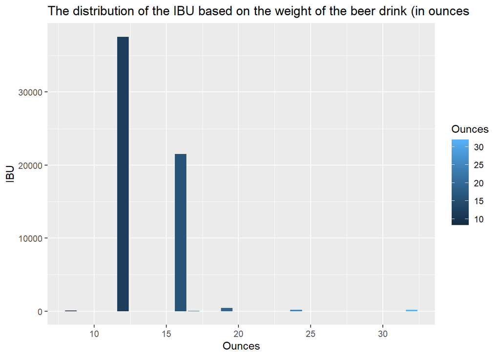

```r
#Visualizing the distribution based on the weight in ounces using a barplot
merged_df %>% group_by(Ounces) %>% ggplot(aes(y = IBU, x = Ounces, fill = Ounces)) + geom_bar(stat = "identity") + ggtitle("The distribution of the IBU based on the weight of the beer drink (in ounces")
```

```r
# The bar just shows the frequency distribution of the IBU for each weight

#Visualizing the distribution based on the IBU using a scatterplot
merged_df %>% group_by(IBU) %>% ggplot(aes(y = ABV, x = IBU, color = State)) + geom_point() + ggtitle("The distribution of the ABV based on each IBU")  + theme(legend.position = "none")
```

[output not shown]

#### Agenda 7: Investigating the relationship between the ABV variable and IBU variable

```r
#Visualizing the distribution based on the ABV vs. IBU using a scatterplot
merged_df %>% group_by(IBU) %>% ggplot(aes(y = ABV, x = IBU, color = State)) + geom_point() + ggtitle("The distribution of the ABV based on each IBU") + theme(legend.position = "none")
```

[output not shown]

#### Question 8: Budweiser would also like to investigate the difference with respect to IBU and ABV between IPAs (India Pale Ales) and other types of Ale (any beer with “Ale” in its name other than IPA). You decide to use KNN classification to investigate this relationship. Provide statistical evidence one way or the other. You can of course assume your audience is comfortable with percentages … KNN is very easy to understand conceptually. In addition, while you have decided to use KNN to investigate this relationship (KNN is required) you may also feel free to supplement your response to this question with any other methods or techniques you have learned. Creativity and alternative solutions are always encouraged.

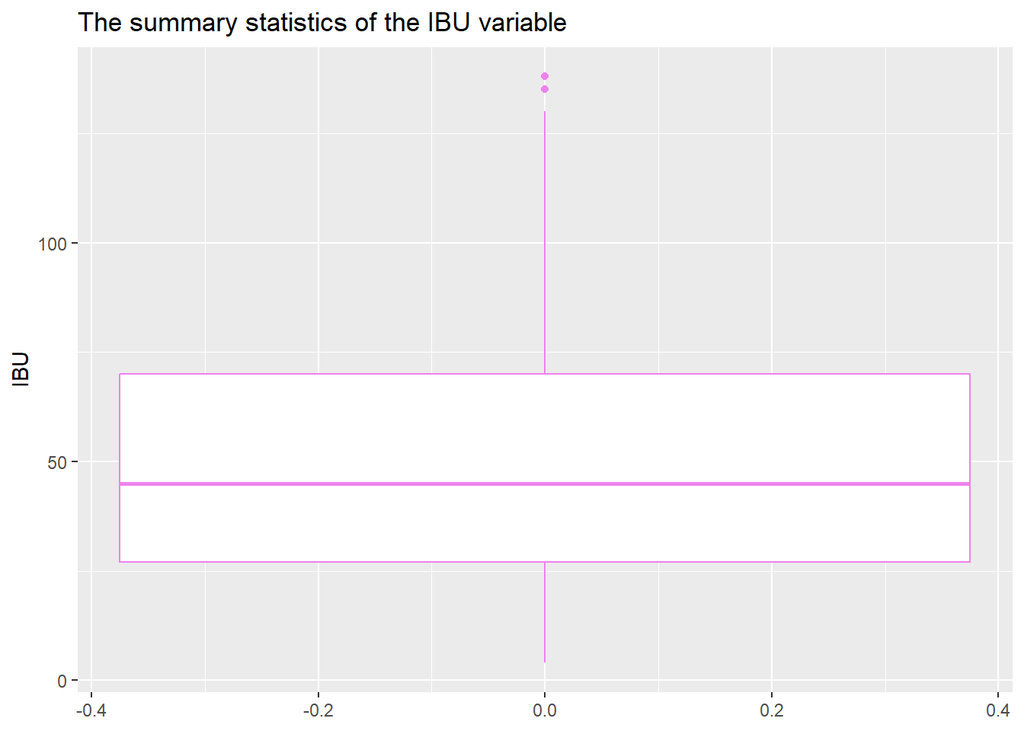

```r
# Using KNNs
set.seed(123)

# Step 1: Data Preprocessing

#Extracting relevant data for the knn
Budweiser_df = merged_df %>% filter(str_detect(Style, "IPA") | (str_detect(Style, "Ale"))) #filtering the IPA and different ale beers using str_filter() & str_detect

#concerting all IPA and Ale variables to groupnames
Budweiser_df2 <- Budweiser_df %>%
  mutate(Style = case_when(
    grepl("IPA", Style, ignore.case = TRUE) ~ "IPA",
    grepl("Ale", Style, ignore.case = TRUE) ~ "Ale",
    TRUE ~ Style  # Keep the original name if no match
  ))

# Step 2: Data Exploration

#Visualizing the distribution of IBU and ABV values for the IPA and beers using a box plot
Budweiser_df2 %>% group_by(IBU) %>% ggplot(aes(y = IBU)) + geom_boxplot(color = 'violet') + ggtitle("The summary statistics of the IBU variable") + theme(legend.position = "none")
```

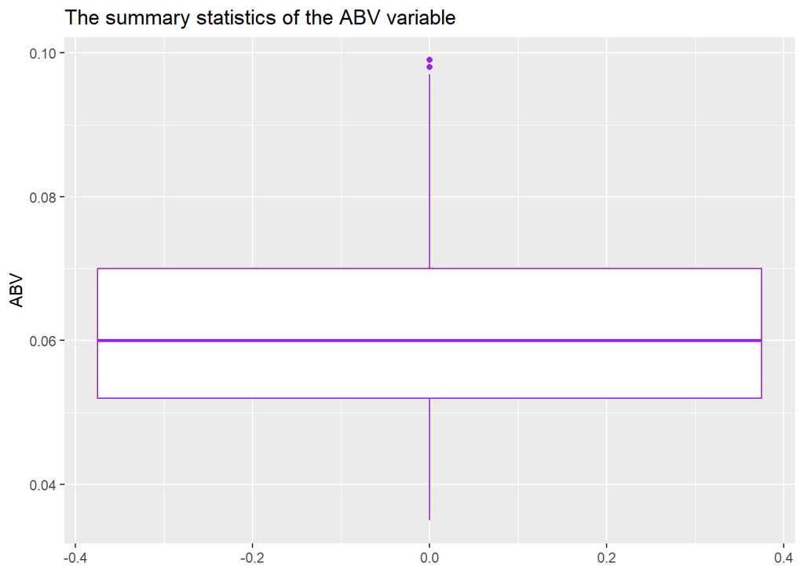

```r
Budweiser_df2 %>% group_by(ABV) %>% ggplot(aes(y = ABV)) + geom_boxplot(color = 'purple') + ggtitle("The summary statistics of the ABV variable") + theme(legend.position = "none")
```

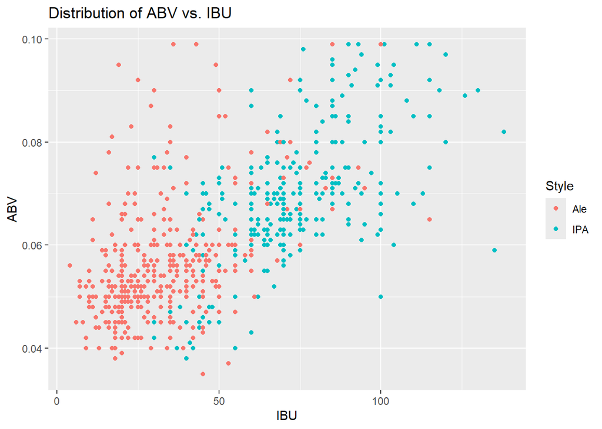

```r
Budweiser_df2 %>% ggplot(aes(x = IBU, y = ABV,color = Style)) + geom_point() +  ggtitle("Distribution of ABV vs. IBU")
```

```r
# Step 3: Data Splitting
#sorting the datasets into training and test data, Using an 80-20 split
split_perc <- 0.80
trainPosition = sample(1:nrow(Budweiser_df2)[1],round(split_perc * nrow(Budweiser_df2)[1])) #getting the index for the training dataset
trainData <- Budweiser_df2[trainPosition, ]
testData <- Budweiser_df2[-trainPosition, ]
trainData; testData
```

```
##     Brewery_id                                           Name.x Beer_ID   ABV
## 415        172                                  Boont Amber Ale    1326 0.058
## 463        199                                      Proxima IPA    1543 0.063
## 179         81                                  Nonstop Hef Hop    2400 0.039
## 526        231                           Imperial Pumpkin Stout    2068 0.099
## 195         81                               Rise-Up Red (2014)    1085 0.058
## 938        534                                      Jockamo IPA     516 0.065
## 818        419                                 Wheat the People     893 0.044
## 118         47                                        Harbinger     629 0.049
## 299        129                    Firemans #4 Blonde Ale (2013)    1718 0.051
## 229         94                                           Cougar    1851 0.048
## 244        105                                   Peach Pale Ale    2434 0.057
## 14           4                                         Jucundus    2666 0.060
## 374        160                             Hop Notch IPA (2013)    1089 0.073
## 665        315                               Black Walnut Wheat     846 0.045
```

[output cut: 2253 more lines]

```
##     Brewery_id                                Name.x Beer_ID   ABV IBU Style
## 1            1                          Get Together    2692 0.045  50   IPA
## 3            1                               Pumpion    2689 0.060  38   Ale
## 7            2                              Sho'nuff    2680 0.040  13   Ale
## 9            2                      Coq de la Marche    2677 0.051  38   Ale
## 12           4                        Habitus (2014)    2668 0.080 100   IPA
## 22          13                             Nordskye     2634 0.048  47   IPA
## 25          14                                  Gold    2632 0.048  15   Ale
## 27          14              Veteran’s Pale Ale (VPA)    2629 0.050  40   Ale
## 28          14                        Grapefruit IPA    2628 0.050  35   IPA
## 32          16                           All Day IPA    1223 0.047  42   IPA
## 35          18                 Overlord Imperial IPA    1449 0.085 115   IPA
## 43          25                          Pale Alement    2478 0.055  40   Ale
## 47          25                          Pale Alement    2054 0.055  40   Ale
## 62          26                     Wee Muckle (2011)     584 0.090  30   Ale
```

[output cut: 365 more lines]

```r
#testing the dimensions of the train and test data

# Check for NA values
print(colSums(is.na(trainData)))
```

```
## Brewery_id     Name.x    Beer_ID        ABV        IBU      Style     Ounces
##          0          0          0          0          0          0          0
##     Name.y       City      State
##          0          0          0
```

```r
print(colSums(is.na(testData)))
```

```
## Brewery_id     Name.x    Beer_ID        ABV        IBU      Style     Ounces
##          0          0          0          0          0          0          0
##     Name.y       City      State
##          0          0          0
```

```r
# Check data types
print(sapply(trainData[, c("IBU", "ABV")], class))
```

```
##       IBU       ABV
## "integer" "numeric"
```

```r
print(sapply(testData[, c("IBU", "ABV")], class))
```

```
##       IBU       ABV
## "integer" "numeric"
```

```r
# Step 4: Building the KNN model
classifications <- knn(trainData[, c("IBU", "ABV")], testData[, c("IBU", "ABV")], trainData$Style, prob = TRUE, k = 5)
#table(classifications, testData$Style)

# Step 5: Model Evaluation
CM = confusionMatrix(table(classifications,testData$Style))
CM
```

```
## Confusion Matrix and Statistics
##
##
## classifications Ale IPA
##             Ale  95  17
##             IPA  10  67
##
##                Accuracy : 0.8571
##                  95% CI : (0.799, 0.9037)
##     No Information Rate : 0.5556
##     P-Value [Acc > NIR] : <2e-16
##
##                   Kappa : 0.7083
##
##  Mcnemar's Test P-Value : 0.2482
##
##             Sensitivity : 0.9048
##             Specificity : 0.7976
##          Pos Pred Value : 0.8482
##          Neg Pred Value : 0.8701
##              Prevalence : 0.5556
##          Detection Rate : 0.5026
##    Detection Prevalence : 0.5926
##       Balanced Accuracy : 0.8512
##
##        'Positive' Class : Ale
##
```

```r
#Statistical Evidence

#Using ttest to compare the mean of IBU and ABV variables
Budweiser_IPA = Budweiser_df2 %>% filter(str_detect(Style, "IPA"))
Budweiser_Ale = Budweiser_df2 %>% filter(str_detect(Style, "Ale"))

t.test(Budweiser_IPA$IBU, Budweiser_Ale$IBU)
```

```
##
##  Welch Two Sample t-test
##
## data:  Budweiser_IPA$IBU and Budweiser_Ale$IBU
## t = 30.118, df = 797.55, p-value < 2.2e-16
## alternative hypothesis: true difference in means is not equal to 0
## 95 percent confidence interval:
##  35.16402 40.06727
## sample estimates:
## mean of x mean of y
##  71.94898  34.33333
```

```r
t.test(Budweiser_IPA$ABV, Budweiser_Ale$ABV)
```

```
##
##  Welch Two Sample t-test
##
## data:  Budweiser_IPA$ABV and Budweiser_Ale$ABV
## t = 16.23, df = 794.65, p-value < 2.2e-16
## alternative hypothesis: true difference in means is not equal to 0
## 95 percent confidence interval:
##  0.01106438 0.01410901
## sample estimates:
##  mean of x  mean of y
## 0.06914286 0.05655616
```

Conclusion

Utilizing various file manipulation, string manipulation and data visualization techniques, we were able to find valuable insight into the data of US craft beers and US breweries, over the past years.

Lastly we were able to use kNN, and a ttest to prove that there is a significant relationship between the IPA drinks and the Ale drinks.